# Cue-task macBP gamma & event-locked spectrograms

Zelano Lab — cueTask analysis

2026-06-30

## 1. Methods

**Data.** Cue-task intracranial/scalp recordings, preprocessed to 500 Hz (high-pass 0.03 Hz, low-pass ~Nyquist, notch 60/120/180 Hz). Analysis channels are the bipolar macro pairs `macBP1..5` (count varies; sessions without any `macBP` are excluded). Sessions are grouped as **DupiS1 / DupiS2 / DupiS3** (Dupi study, recording session 1/2/3) and **Control** (all non-Dupi cue sessions).

**FOOOF (Task 1).** Per session, each `macBP` PSD (FieldTrip `ft_freqanalysis`, `mtmfft`, 2 s segments, 50% overlap, piped in via EEGLAB `eeglab2fieldtrip`) was parameterized with FOOOF over **2–58 Hz** with a **knee** aperiodic term (`cfg.output = fooof_aperiodic / fooof_peaks`; brainstorm `process_fooof`). *(The knee + restricted 2–58 Hz range follows the low-frequency 1/f bend; an earlier 2–120 Hz fixed-aperiodic fit mis-modeled the 1/f and inflated apparent gamma-peak heights.)* The **gamma** band is 30–58 Hz. Before selecting `bestMac`, each channel’s **trial-rejection rate** is estimated (fraction of trialStart epochs flagged as noisy by the relative sharp-deflection rule, below); channels where this rate exceeds **30%** are excluded from bestMac consideration, preventing a high-noise channel whose broadband artifact mimics a gamma peak from being selected. Among the remaining (clean) channels: `bestMac` is the channel with the largest **periodic** (oscillatory) gamma peak; if no clean `macBP` channel has a fitted gamma peak we fall back to the largest **flattened** (PSD ÷ aperiodic) power; if all channels exceed the 30% threshold we select the least-noisy one (`selectionMethod = 'allNoisy_leastBad'`). The `selectionMethod` and per-channel `rejRate` columns record the outcome.

**Spectrograms (Tasks 1–4, z-score method).** For each session’s `bestMac`, per-trial time-frequency power was obtained from EEGLAB `newtimef` (Morlet, 100 log-spaced freqs 2–120 Hz; single-trial `alltfX` → |·|²), locked to **trialStart** and to **finalOnset** (finalOnset is ~6 s after trialStart). Power was normalized with a **bootstrap permutation z-score** (`myChanZscore`): per frequency, a 1000-sample bootstrap distribution of the **−700…−200 ms trialStart baseline** mean defines the z reference. The finalOnset epoch is z-scored against the **same trialStart baseline** (its baseline frames are appended before z-scoring), so the two lockings share one scale (heat = *z vs baseline*).

## 2. Data available

Cue sessions analysed (one row per session).

[output not shown]

## 3. FOOOF findings

Selected bestMac channel per session.

|  | sessID | group | channel | gammaPeakDetected | peakGammaFreq | peakGammaPower | flattenedGammaMax | selectionMethod |
| --- | --- | --- | --- | --- | --- | --- | --- | --- |
| 3 | 230611_OBE_NMH_AZ | Control | macBP3 | 1 | 50.776 | 0.476 | 10.456 | periodicPeak |
| 7 | 240923_OBE_NMH_HRM | Control | macBP2 | 1 | 41.895 | 0.041 | 0.807 | periodicPeak |
| 14 | 250313_OBE_NMH_CS | Control | macBP4 | 1 | 42.450 | 1.511 | 16.037 | periodicPeak |
| 18 | 250623_Dupi_NMH_KS_2 | DupiS2 | macBP3 | 1 | 36.041 | 0.663 | 6.879 | periodicPeak |
| 21 | 250818_Dupi_NMH_JH_2 | DupiS2 | macBP1 | 1 | 45.024 | 0.384 | 4.327 | periodicPeak |
| 27 | 250811_Dupi_NMH_TB_2 | DupiS2 | macBP2 | 1 | 43.174 | 0.454 | 4.334 | periodicPeak |
| 32 | 251002_Dupi_NMH_AB_1 | DupiS1 | macBP2 | 1 | 32.220 | 0.943 | 9.197 | periodicPeak |
| 38 | 250929_Dupi_NMH_GH_2 | DupiS2 | macBP3 | 1 | 35.338 | 0.853 | 7.335 | periodicPeak |
| 40 | 251013_Dupi_NMH_JN_2 | DupiS2 | macBP2 | 1 | 35.723 | 0.994 | 10.338 | periodicPeak |
| 43 | 251030_Dupi_NMH_DB_1 | DupiS1 | macBP1 | 1 | 30.016 | 1.065 | 9.756 | periodicPeak |
| 48 | 251120_Dupi_NMH_JL_1 | DupiS1 | macBP1 | 1 | 40.870 | 0.931 | 9.659 | periodicPeak |
| 54 | 251030_Dupi_NMH_DB_2 | DupiS2 | macBP2 | 1 | 33.200 | 1.313 | 11.452 | periodicPeak |
| 55 | 251120_Dupi_NMH_JL_2 | DupiS2 | macBP1 | 1 | 40.883 | 0.963 | 10.012 | periodicPeak |
| 62 | 250929_Dupi_NMH_GH_3 | DupiS3 | macBP3 | 1 | 31.806 | 0.976 | 7.836 | periodicPeak |
| 67 | 251013_Dupi_NMH_JN_3 | DupiS3 | macBP5 | 1 | 53.269 | 0.510 | 7.825 | periodicPeak |
| 70 | 260326_OBE_NWU_AD_2 | Control | macBP3 | 1 | 31.925 | 0.729 | 8.725 | periodicPeak |
| 75 | 260504_Dupi_NMH_JA_1 | DupiS1 | macBP3 | 1 | 34.751 | 1.442 | 12.470 | periodicPeak |
| 79 | 260514_OBE_NWU_BW_1 | Control | macBP2 | 1 | 40.926 | 0.679 | 6.748 | periodicPeak |
| 82 | 241017_OBE_NMH_AS | Control | macBP2 | 1 | 45.008 | 0.986 | 12.782 | periodicPeak |
| 86 | 250310_OBE_NMH_FS | Control | macBP1 | 1 | 36.980 | 1.335 | 13.338 | periodicPeak |
| 92 | 250623_Dupi_NMH_KS_1 | DupiS1 | macBP2 | 1 | 36.174 | 0.555 | 5.639 | periodicPeak |
| 96 | 250818_Dupi_NMH_JH_1 | DupiS1 | macBP2 | 1 | 39.962 | 0.848 | 8.639 | periodicPeak |
| 100 | 250811_Dupi_NMH_TPB_1 | DupiS1 | macBP1 | 1 | 50.129 | 0.611 | 5.154 | periodicPeak |
| 107 | 250929_Dupi_NMH_GH_1 | DupiS1 | macBP3 | 1 | 35.560 | 0.863 | 6.763 | periodicPeak |
| 110 | 251027_Dupi_NMH_DL_1 | DupiS1 | macBP2 | 1 | 36.327 | 0.947 | 10.118 | periodicPeak |
| 115 | 251002_Dupi_NMH_AB_2 | DupiS2 | macBP2 | 1 | 55.248 | 1.302 | 12.222 | periodicPeak |
| 117 | 250623_Dupi_NMH_KS_3 | DupiS3 | macBP2 | 1 | 39.045 | 0.500 | 5.287 | periodicPeak |
| 121 | 251110_Dupi_NMH_PC_1 | DupiS1 | macBP1 | 1 | 30.224 | 0.847 | 8.307 | periodicPeak |
| 125 | 250818_Dupi_NMH_JH_3 | DupiS3 | macBP4 | 1 | 38.823 | 0.927 | 8.944 | periodicPeak |
| 127 | 251110_Dupi_NMH_PC_2 | DupiS2 | macBP1 | 1 | 33.194 | 0.300 | 4.774 | periodicPeak |
| 129 | 250811_Dupi_NMH_TB_3 | DupiS3 | macBP1 | 1 | 42.482 | 0.608 | 6.277 | periodicPeak |
| 134 | 251002_Dupi_NMH_AB_3 | DupiS3 | macBP1 | 1 | 31.924 | 0.990 | 9.806 | periodicPeak |
| 139 | 260406_Dupi_NMH_BS_1 | DupiS1 | macBP5 | 1 | 56.325 | 0.552 | 6.143 | periodicPeak |
| 142 | 260316_Dupi_NMH_PD_1 | DupiS1 | macBP3 | 1 | 41.126 | 0.730 | 6.642 | periodicPeak |
| 148 | 260406_Dupi_NMH_BS_2 | DupiS2 | macBP4 | 1 | 56.293 | 0.478 | 5.841 | periodicPeak |

All macBP channels.

| sessID | group | channel | gammaPeakDetected | peakGammaFreq | peakGammaPower | flattenedGammaMax | aperiodicExponent | fooofR2 | isBestMac |
| --- | --- | --- | --- | --- | --- | --- | --- | --- | --- |
| 230611_OBE_NMH_AZ | Control | macBP1 | 1 | 51.103 | 0.395 | 10.934 | 1.631 | 0.979 | 0 |
| 230611_OBE_NMH_AZ | Control | macBP2 | 1 | 46.151 | 0.338 | 10.962 | 1.615 | 0.979 | 0 |
| 230611_OBE_NMH_AZ | Control | macBP3 | 1 | 50.776 | 0.476 | 10.456 | 1.619 | 0.984 | 1 |
| 230611_OBE_NMH_AZ | Control | macBP4 | 1 | 50.322 | 0.335 | 10.903 | 1.881 | 0.988 | 0 |
| 230611_OBE_NMH_AZ | Control | macBP5 | 1 | 50.680 | 0.406 | 13.137 | 1.490 | 0.973 | 0 |
| 240923_OBE_NMH_HRM | Control | macBP1 | 0 | NaN | NaN | 1.466 | 1.989 | 0.987 | 0 |
| 240923_OBE_NMH_HRM | Control | macBP2 | 1 | 41.895 | 0.041 | 0.807 | 2.511 | 0.999 | 1 |
| 240923_OBE_NMH_HRM | Control | macBP3 | 0 | NaN | NaN | 1.767 | 2.005 | 0.996 | 0 |
| 240923_OBE_NMH_HRM | Control | macBP4 | 0 | NaN | NaN | 1.593 | 1.694 | 0.992 | 0 |
| 240923_OBE_NMH_HRM | Control | macBP5 | 1 | 32.653 | 0.067 | 0.924 | 1.798 | 0.958 | 0 |
| 250313_OBE_NMH_CS | Control | macBP1 | 1 | 41.268 | 0.855 | 8.996 | 1.687 | 0.998 | 0 |
| 250313_OBE_NMH_CS | Control | macBP2 | 1 | 42.062 | 1.422 | 14.768 | 0.942 | 0.990 | 0 |
| 250313_OBE_NMH_CS | Control | macBP3 | 1 | 41.525 | 1.435 | 14.932 | 0.510 | 0.977 | 0 |
| 250313_OBE_NMH_CS | Control | macBP4 | 1 | 42.450 | 1.511 | 16.037 | 0.451 | 0.978 | 1 |
| 250313_OBE_NMH_CS | Control | macBP5 | 1 | 42.141 | 1.367 | 14.473 | 0.730 | 0.984 | 0 |
| 250623_Dupi_NMH_KS_2 | DupiS2 | macBP1 | 1 | 37.132 | 0.296 | 3.133 | 1.357 | 0.994 | 0 |
| 250623_Dupi_NMH_KS_2 | DupiS2 | macBP2 | 1 | 36.129 | 0.525 | 5.455 | 1.194 | 0.993 | 0 |
| 250623_Dupi_NMH_KS_2 | DupiS2 | macBP3 | 1 | 36.041 | 0.663 | 6.879 | 1.153 | 0.991 | 1 |
| 250623_Dupi_NMH_KS_2 | DupiS2 | macBP4 | 1 | 36.552 | 0.329 | 3.518 | 1.235 | 0.993 | 0 |
| 250623_Dupi_NMH_KS_2 | DupiS2 | macBP5 | 1 | 34.959 | 0.145 | 1.548 | 1.742 | 0.998 | 0 |
| 250818_Dupi_NMH_JH_2 | DupiS2 | macBP1 | 1 | 45.024 | 0.384 | 4.327 | 1.834 | 0.988 | 1 |
| 250818_Dupi_NMH_JH_2 | DupiS2 | macBP2 | 1 | 37.907 | 0.417 | 4.423 | 1.015 | 0.987 | 0 |
| 250818_Dupi_NMH_JH_2 | DupiS2 | macBP3 | 1 | 53.766 | 0.361 | 4.151 | 2.048 | 0.993 | 0 |
| 250818_Dupi_NMH_JH_2 | DupiS2 | macBP4 | 0 | NaN | NaN | 1.520 | 1.131 | 0.945 | 0 |
| 250818_Dupi_NMH_JH_2 | DupiS2 | macBP5 | 0 | NaN | NaN | 1.377 | 1.191 | 0.957 | 0 |
| 250811_Dupi_NMH_TB_2 | DupiS2 | macBP1 | 1 | 44.861 | 0.285 | 2.560 | 1.059 | 0.989 | 0 |
| 250811_Dupi_NMH_TB_2 | DupiS2 | macBP2 | 1 | 43.174 | 0.454 | 4.334 | 0.742 | 0.974 | 1 |
| 250811_Dupi_NMH_TB_2 | DupiS2 | macBP3 | 1 | 41.718 | 0.358 | 3.188 | 0.758 | 0.985 | 0 |
| 250811_Dupi_NMH_TB_2 | DupiS2 | macBP4 | 1 | 45.877 | 0.391 | 5.120 | 0.414 | 0.975 | 0 |
| 250811_Dupi_NMH_TB_2 | DupiS2 | macBP5 | 1 | 41.287 | 0.158 | 1.518 | 1.103 | 0.996 | 0 |

[output cut: 118 more lines]

## 3b. Trial noise rejection (relative sharp-deflection rule)

`nTrials` = trialStart events; `nNoiseTrials` = trials flagged by the **relative** sharp- deflection rule (any 10 ms window with `zd > 10`, i.e. >10 robust-SDs above that channel’s typical 10 ms swing; drawn red on `singleTrialRawMac.png` and excluded); `nFinal_*` = clean trials entering each locking’s average (`nFinal_finalOnset` is further limited by epochs running off the recording end, `nOOB_finalOnset`).

Per-session noise rejection for the bestMac spectrograms.

|  | sessID | group | nTrials | nNoiseTrials | nOOB_finalOnset | nFinal_trialStart | nFinal_finalOnset |
| --- | --- | --- | --- | --- | --- | --- | --- |
| 3 | 230611_OBE_NMH_AZ | Control | 40 | 10 | 0 | 30 | 30 |
| 7 | 240923_OBE_NMH_HRM | Control | 40 | 0 | 0 | 40 | 40 |
| 14 | 250313_OBE_NMH_CS | Control | 40 | 0 | 0 | 39 | 39 |
| 18 | 250623_Dupi_NMH_KS_2 | DupiS2 | 40 | 0 | 0 | 40 | 40 |
| 21 | 250818_Dupi_NMH_JH_2 | DupiS2 | 40 | 10 | 0 | 28 | 28 |
| 27 | 250811_Dupi_NMH_TB_2 | DupiS2 | 40 | 1 | 0 | 36 | 36 |
| 32 | 251002_Dupi_NMH_AB_1 | DupiS1 | 40 | 5 | 0 | 34 | 34 |
| 38 | 250929_Dupi_NMH_GH_2 | DupiS2 | 40 | 6 | 0 | 34 | 34 |
| 40 | 251013_Dupi_NMH_JN_2 | DupiS2 | 40 | 3 | 0 | 37 | 37 |
| 43 | 251030_Dupi_NMH_DB_1 | DupiS1 | 40 | 4 | 0 | 34 | 34 |
| 48 | 251120_Dupi_NMH_JL_1 | DupiS1 | 40 | 1 | 0 | 39 | 39 |
| 54 | 251030_Dupi_NMH_DB_2 | DupiS2 | 40 | 0 | 0 | 37 | 37 |
| 55 | 251120_Dupi_NMH_JL_2 | DupiS2 | 39 | 3 | 0 | 36 | 36 |
| 62 | 250929_Dupi_NMH_GH_3 | DupiS3 | 40 | 4 | 0 | 36 | 36 |
| 67 | 251013_Dupi_NMH_JN_3 | DupiS3 | 40 | 3 | 0 | 37 | 37 |
| 70 | 260326_OBE_NWU_AD_2 | Control | 60 | 0 | 0 | 60 | 60 |
| 75 | 260504_Dupi_NMH_JA_1 | DupiS1 | 40 | 0 | 0 | 40 | 40 |
| 79 | 260514_OBE_NWU_BW_1 | Control | 40 | 0 | 0 | 40 | 40 |
| 82 | 241017_OBE_NMH_AS | Control | 40 | 0 | 0 | 40 | 40 |
| 86 | 250310_OBE_NMH_FS | Control | 40 | 0 | 0 | 40 | 40 |
| 92 | 250623_Dupi_NMH_KS_1 | DupiS1 | 40 | 1 | 0 | 39 | 39 |
| 96 | 250818_Dupi_NMH_JH_1 | DupiS1 | 40 | 1 | 0 | 39 | 39 |
| 100 | 250811_Dupi_NMH_TPB_1 | DupiS1 | 40 | 4 | 0 | 34 | 34 |
| 107 | 250929_Dupi_NMH_GH_1 | DupiS1 | 40 | 3 | 0 | 35 | 35 |
| 110 | 251027_Dupi_NMH_DL_1 | DupiS1 | 40 | 1 | 0 | 38 | 38 |
| 115 | 251002_Dupi_NMH_AB_2 | DupiS2 | 40 | 11 | 0 | 29 | 29 |
| 117 | 250623_Dupi_NMH_KS_3 | DupiS3 | 40 | 3 | 0 | 37 | 37 |
| 121 | 251110_Dupi_NMH_PC_1 | DupiS1 | 40 | 0 | 0 | 36 | 36 |
| 125 | 250818_Dupi_NMH_JH_3 | DupiS3 | 40 | 1 | 0 | 38 | 38 |
| 127 | 251110_Dupi_NMH_PC_2 | DupiS2 | 40 | 3 | 0 | 36 | 36 |
| 129 | 250811_Dupi_NMH_TB_3 | DupiS3 | 40 | 2 | 0 | 31 | 31 |
| 134 | 251002_Dupi_NMH_AB_3 | DupiS3 | 39 | 11 | 0 | 28 | 28 |
| 139 | 260406_Dupi_NMH_BS_1 | DupiS1 | 40 | 11 | 0 | 29 | 29 |
| 142 | 260316_Dupi_NMH_PD_1 | DupiS1 | 40 | 1 | 0 | 39 | 39 |
| 148 | 260406_Dupi_NMH_BS_2 | DupiS2 | 40 | 6 | 0 | 34 | 34 |

### Example single-trial noise plots

Two sessions with the **most** flagged-noise trials and two with the **fewest**, showing the red-flagged single-trial raw `bestMac` traces.

**Highest-noise sessions:**

*251002_Dupi_NMH_AB_2 (DupiS2) — 11 noise trials*

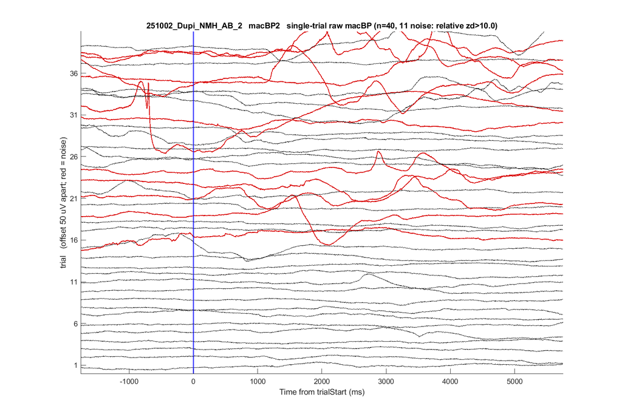

*251002_Dupi_NMH_AB_3 (DupiS3) — 11 noise trials*

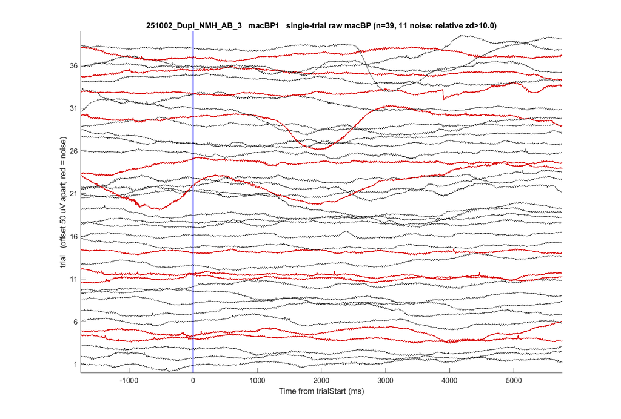

**Lowest-noise sessions:**

*250310_OBE_NMH_FS (Control) — 0 noise trials*

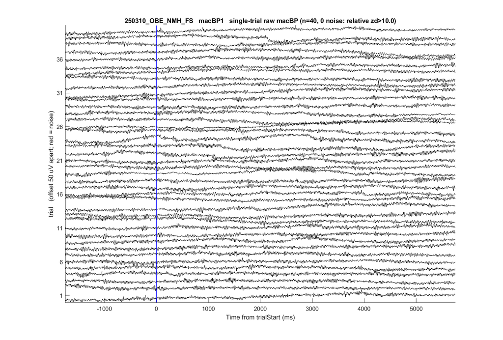

*251110_Dupi_NMH_PC_1 (DupiS1) — 0 noise trials*

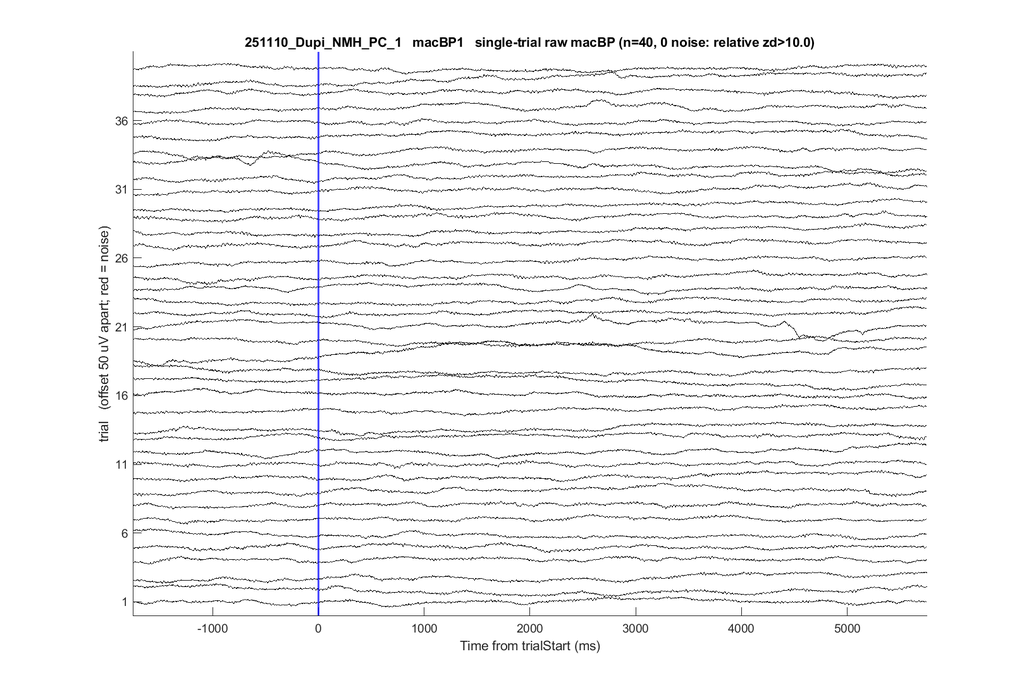

## 4. Single-subject example spectrograms

For each group, up to two example sessions, both lockings (trialStart, finalOnset).

### DupiS1

**250623_Dupi_NMH_KS_1** (bestMac = macBP2)

*trialStart-locked:*

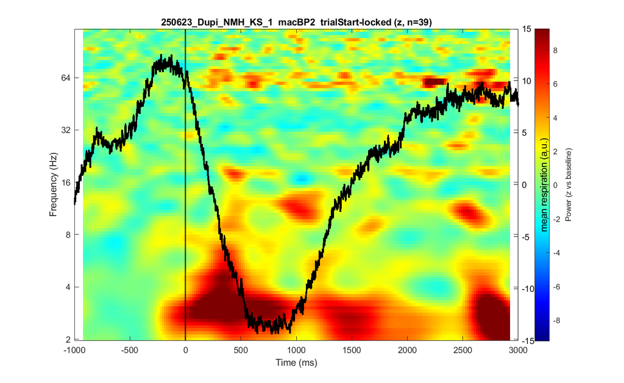

*finalOnset-locked:*

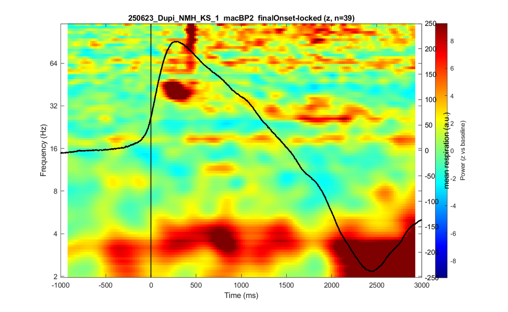

**250818_Dupi_NMH_JH_1** (bestMac = macBP2)

*trialStart-locked:*

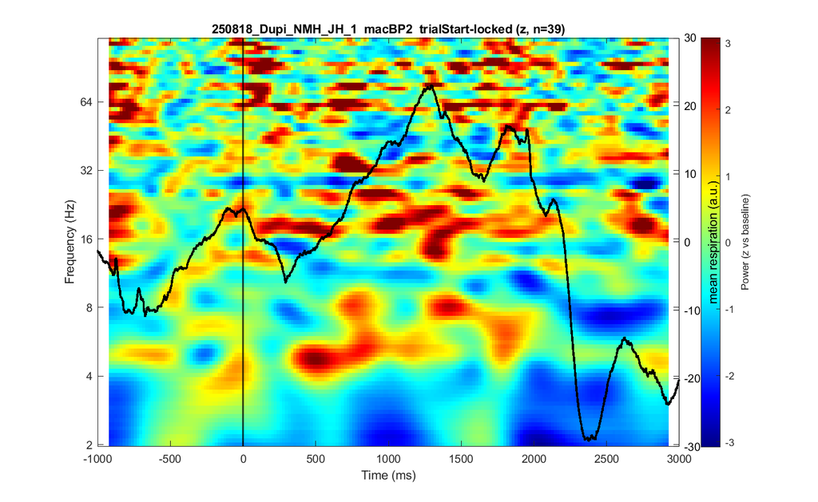

*finalOnset-locked:*

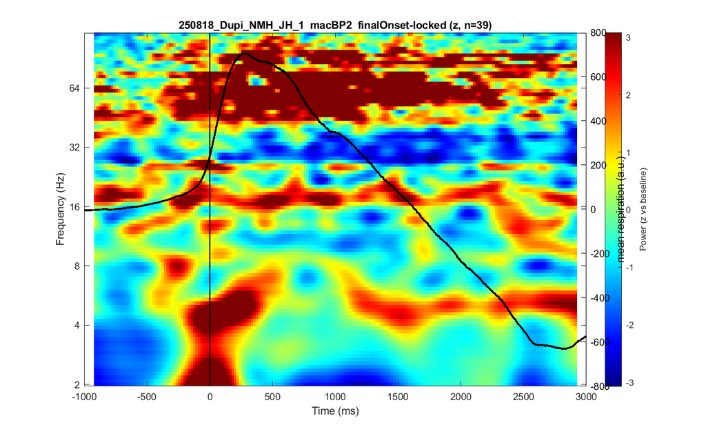

### DupiS2

**250623_Dupi_NMH_KS_2** (bestMac = macBP3)

*trialStart-locked:*

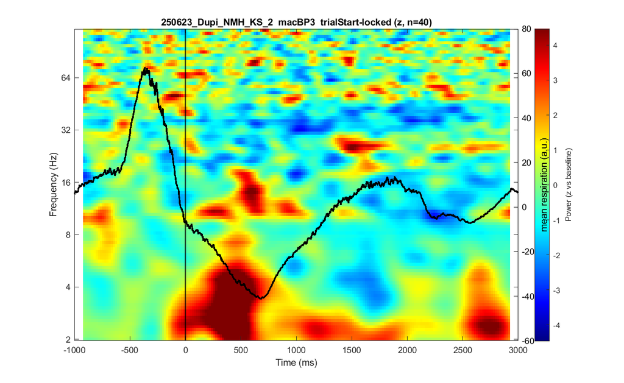

*finalOnset-locked:*

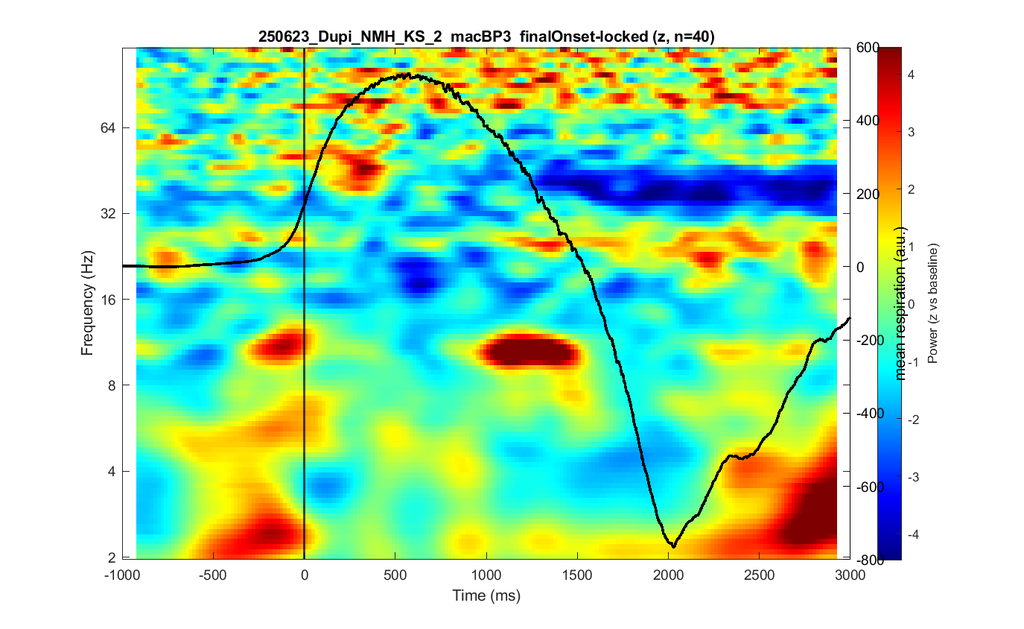

*trialStart-locked:*

[figure not shown]

*finalOnset-locked:*

[figure not shown]

### DupiS3

**250623_Dupi_NMH_KS_3** (bestMac = macBP2)

*trialStart-locked:*

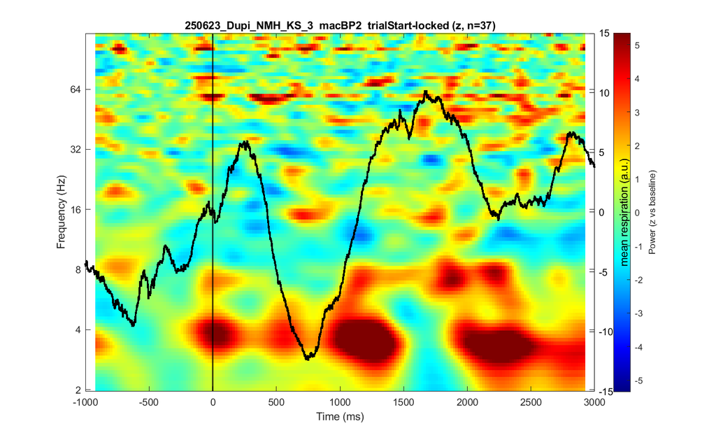

*finalOnset-locked:*

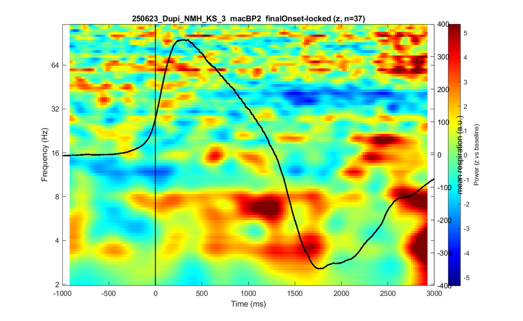

**250818_Dupi_NMH_JH_3** (bestMac = macBP4)

*trialStart-locked:*

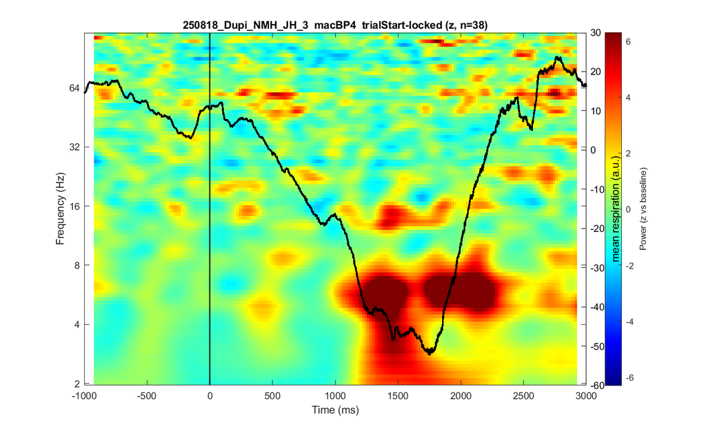

*finalOnset-locked:*

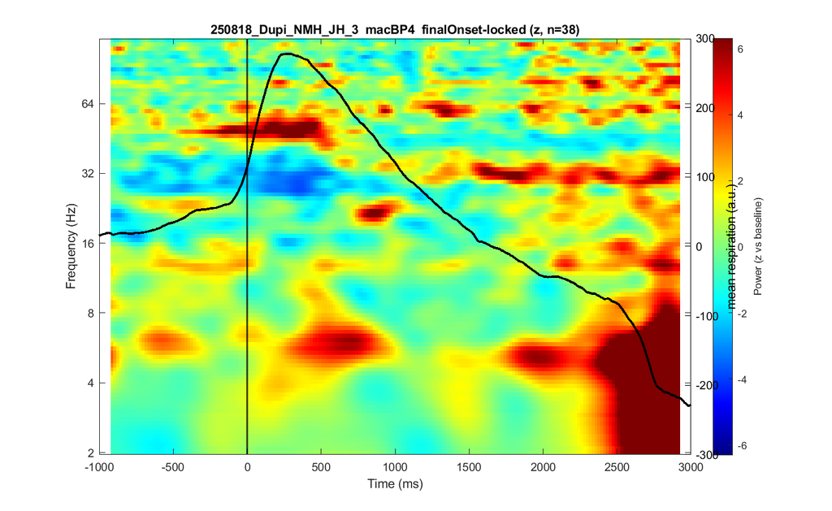

### Control

**230611_OBE_NMH_AZ** (bestMac = macBP3)

*trialStart-locked:*

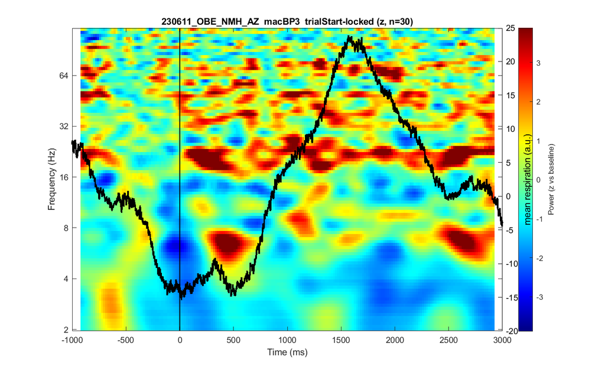

*finalOnset-locked:*

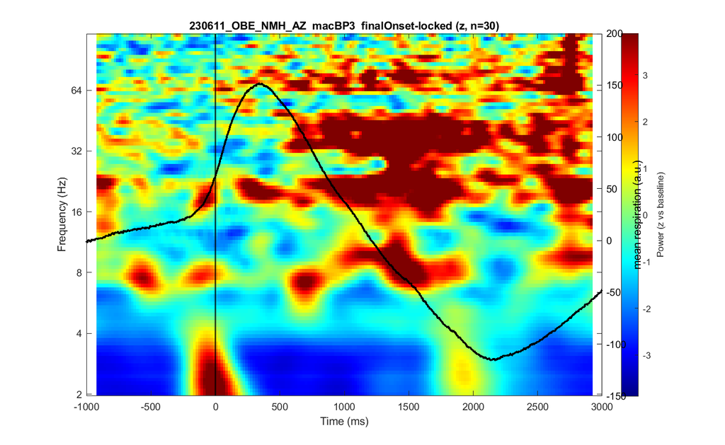

**241017_OBE_NMH_AS** (bestMac = macBP2)

*trialStart-locked:*

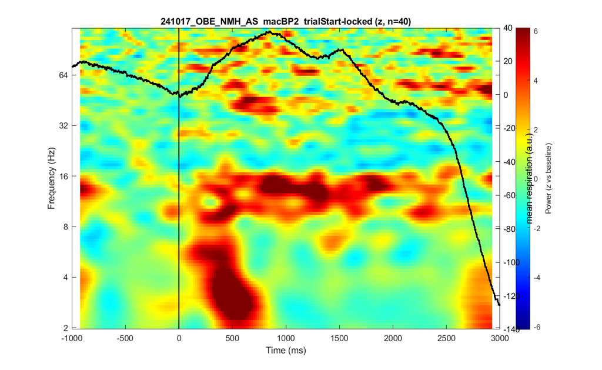

*finalOnset-locked:*

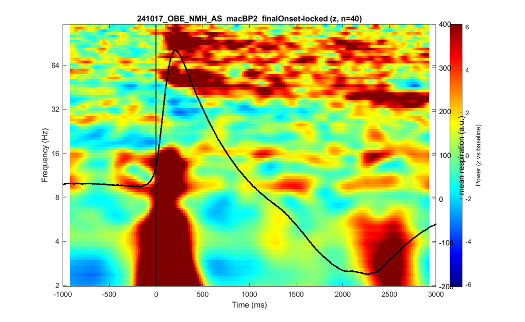

## 5. Group-average spectrograms

### DupiS1

*trialStart-locked:*

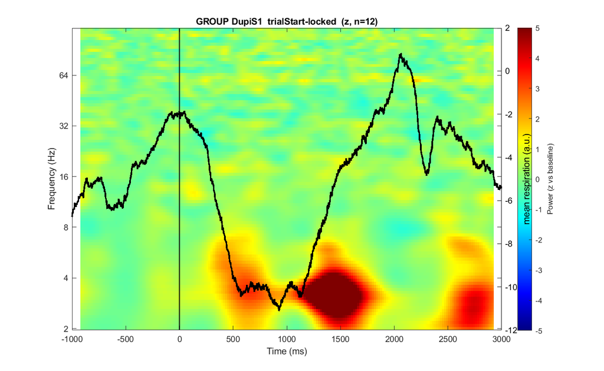

*finalOnset-locked:*

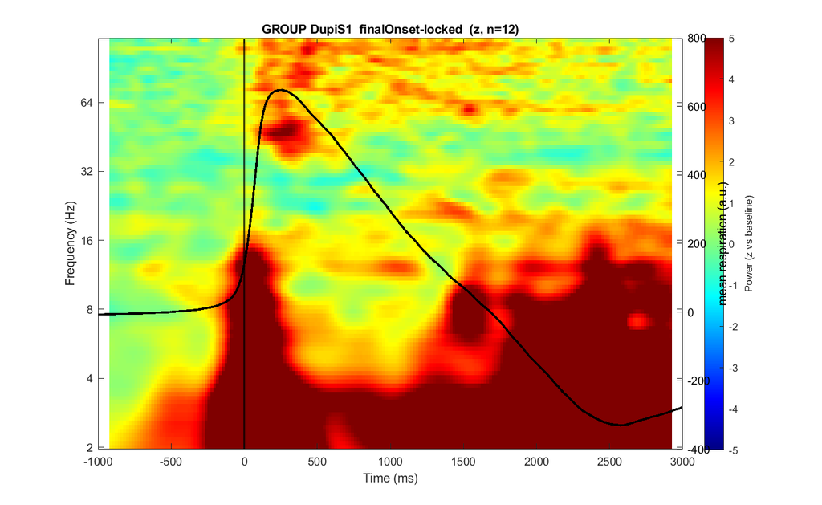

### DupiS2

*trialStart-locked:*

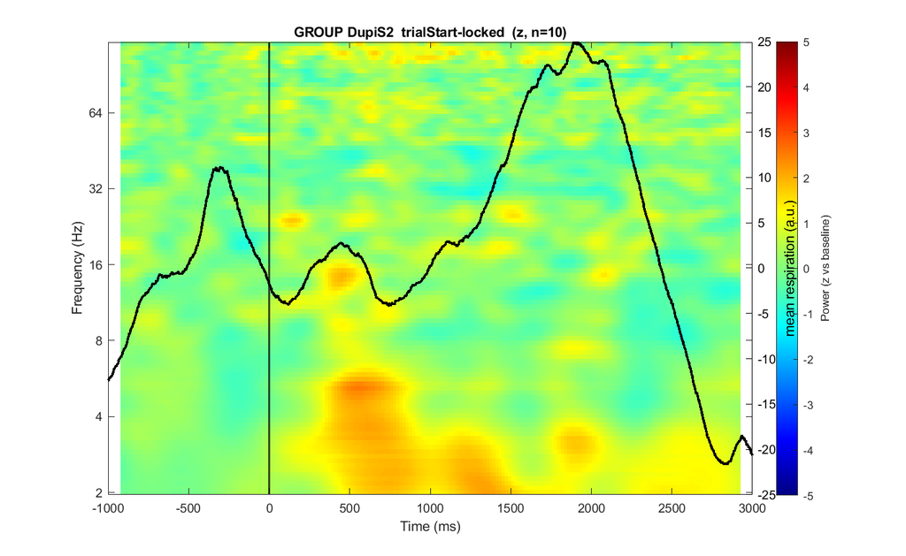

*finalOnset-locked:*

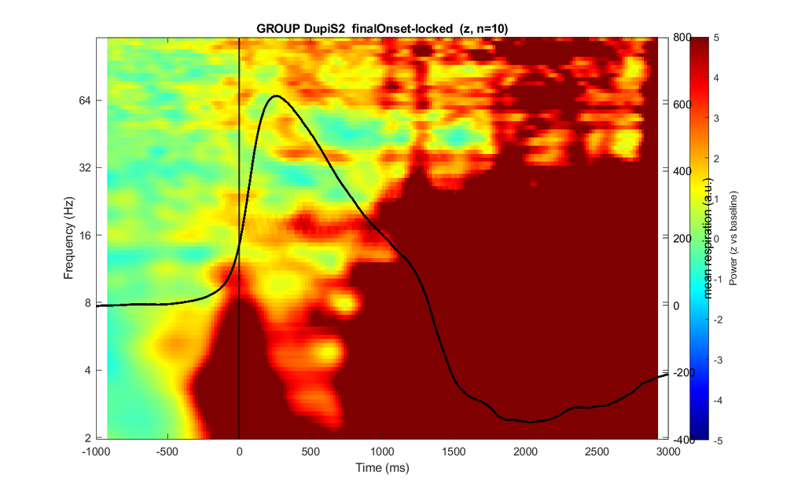

### DupiS3

*trialStart-locked:*

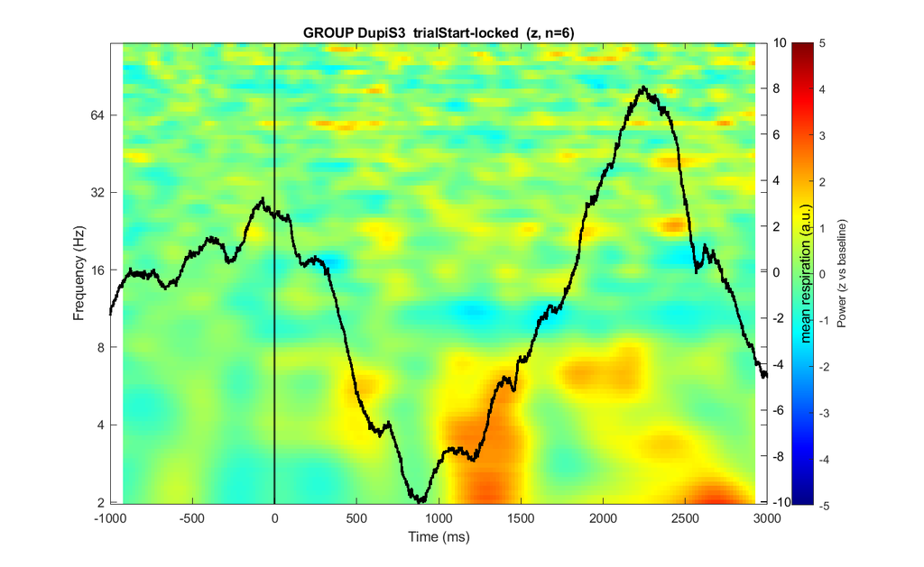

*finalOnset-locked:*

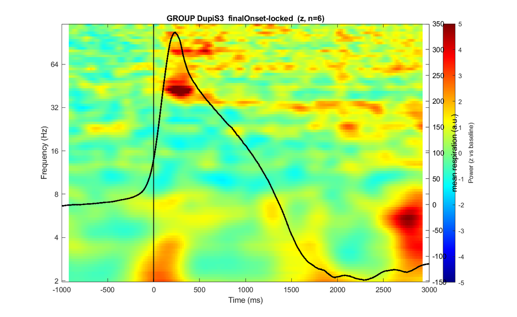

### Control

*trialStart-locked:*

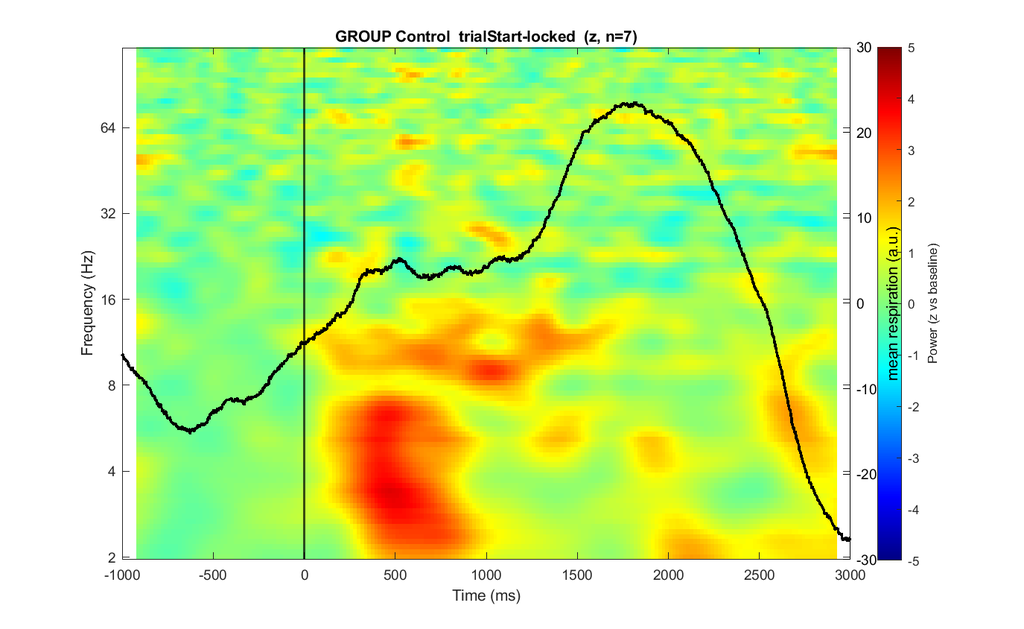

*finalOnset-locked:*

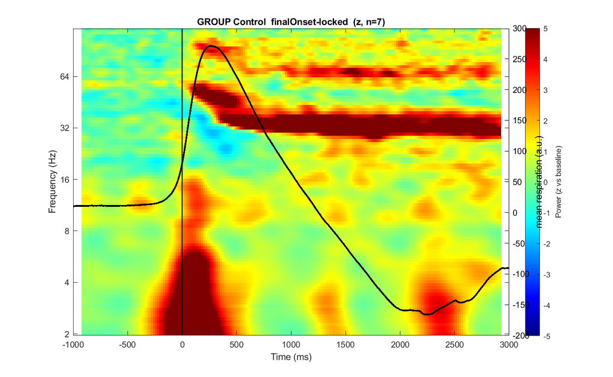

## 6. Time-resolved gamma (FOOOF over epochs)

**Methods.** For each session’s `bestMac`, Morlet power (2–58 Hz, 100 linear freqs) was computed on the noise-clean finalOnset-locked trials, then averaged over trials and into ten sequential **250 ms windows** spanning −500…+2000 ms. FOOOF (same settings as the overall channel fit) was applied to each window’s power spectrum; the largest 30–58 Hz periodic peak per window is recorded in `cueTask_gammaEpochs.csv`. “Channel-centered” = each window’s gamma peak frequency minus that channel’s overall gamma peak (from §3).

### 6.1 Example gamma time-progression (one per group)

**250623_Dupi_NMH_KS_1 (DupiS1)**

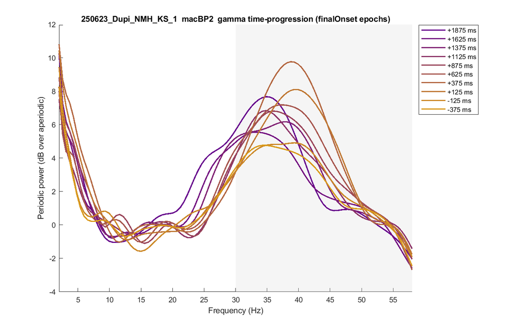

**250623_Dupi_NMH_KS_2 (DupiS2)**

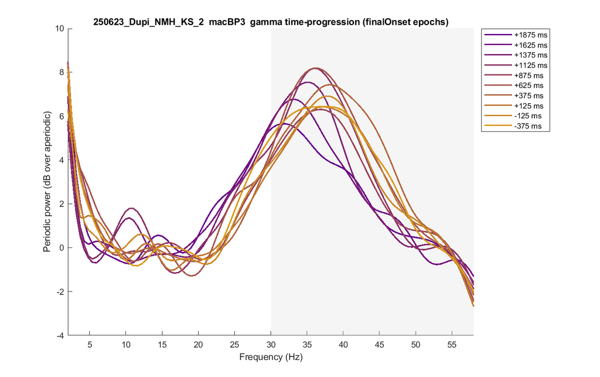

**250623_Dupi_NMH_KS_3 (DupiS3)**

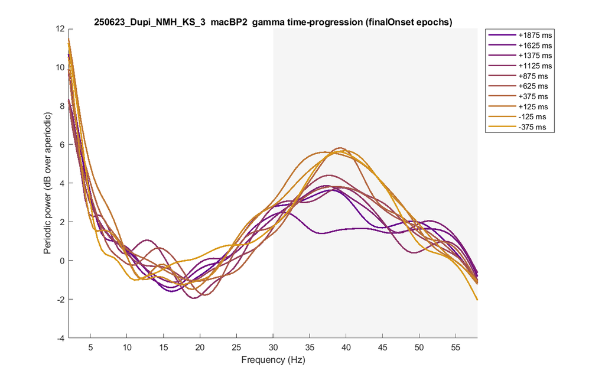

**230611_OBE_NMH_AZ (Control)**

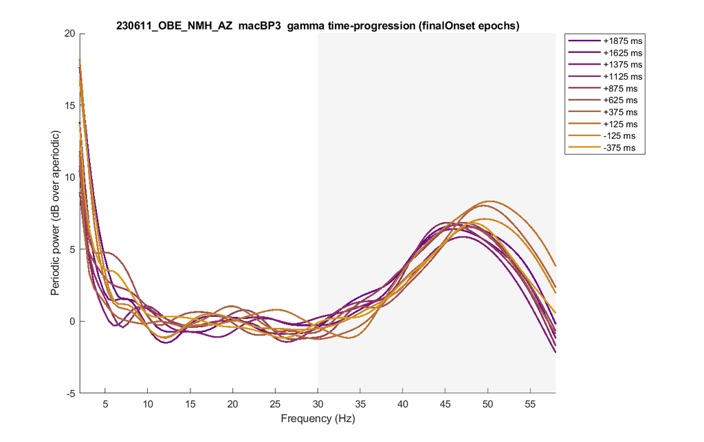